# TIME SERIES | ARIMA | SARIMA MODELS USING PYTHON

### What is Time Series?

- According to the wikipedia, A time series is a series of data points indexed (or listed or graphed) in time order. Most commonly, a time series is a sequence taken at successive equally spaced points in time. Thus it is a sequence of discrete-time data. For example, stock prices over a fixed period of time, hotel bookings, ecommerce sales, waether cycle reports etc.
- Time series analysis comprises methods for analyzing time series data in order to extract meaningful statistics and other characteristics of the data. Time series forecasting is the use of a model to predict future values based on previously observed values.

### Examples of time series data:

- Stock prices, Sales demand, website traffic, daily temperatures, quarterly sales.

### Components of a Time Series:

- Trend
- Seasonality

### What is a TREND in time series?

- Trend is a pattern in data that shows the movement of a series to relatively higher or lower values over a long period of time.
- Trend usually happens for some time and then disappears, it does not repeat. For example, some new kaggle kernels, it goes trending for a while, and then disappears. There is fairly any chance that it would be trending again.

**A trend could be :**

- **UPTREND**: Time Series Analysis shows a general pattern that is upward then it is Uptrend.
- **DOWNTREND**: Time Series Analysis shows a pattern that is downward then it is Downtrend.
- **HORIZONTAL TREND**: If no pattern observed then it is called a Horizontal or stationary trend.

[figure not shown]

### What is SEASONALITY?

- Predictable pattern that recurs or repeats over regular intervals. Seasonality is often observed within a year or less.

[figure not shown]

### Modelling and evaluation Techniques:

- MODELS: Naive approach, Moving average, Simple exponential smoothing, Holt.s linear trend model, Auto Regression Integrated Moving Average(ARIMA), SARIMAX, etc.
- Mean Square Error(MSE), Root Mean Squared Error(RMSE)

# TIME SERIES MODELING - ARIMA, SARIMA

### ARIMA

- Autoregressive Integrated Moving Average, or ARIMA, is a forecasting method for univariate time series data.
- As its name suggests, it supports both an autoregressive and moving average elements. The integrated element refers to differencing allowing the method to support time series data with a trend.
- A problem with ARIMA is that it does not support seasonal data. That is a time series with a repeating cycle.
- ARIMA expects data that is either not seasonal or has the seasonal component removed, e.g. seasonally adjusted via methods such as seasonal differencing.

### SARIMA

- Seasonal Autoregressive Integrated Moving Average, SARIMA or Seasonal ARIMA, is an extension of ARIMA that explicitly supports univariate time series data with a seasonal component.
- It adds three new hyperparameters to specify the autoregression (AR), differencing (I) and moving average (MA) for the seasonal component of the series, as well as an additional parameter for the period of the seasonality.
- A seasonal ARIMA model is formed by including additional seasonal terms in the ARIMA.
- The seasonal part of the model consists of terms that are very similar to the non-seasonal components of the model, but they involve backshifts of the seasonal period.

### The general process for ARIMA models is the following:

- Visualize the Time Series Data
- Make the time series data stationary
- Plot the Correlation and AutoCorrelation Charts
- Construct the ARIMA Model or Seasonal ARIMA based on the data
- Use the model to make prediction

# PYTHON IMPLEMENTATION

### 1. BASIC STEPS OF A PROJECT:

```python
import numpy as np
import pandas as pd

import matplotlib.pyplot as plt
%matplotlib inline
```

```python
df=pd.read_csv('Perrin Freres monthly champagne sales millions.csv')
```

```python
df.head()
```

|  | Month | Perrin Freres monthly champagne sales millions ?64-?72 |
| --- | --- | --- |
| 0 | 1964-01 | 2815.0 |
| 1 | 1964-02 | 2672.0 |
| 2 | 1964-03 | 2755.0 |
| 3 | 1964-04 | 2721.0 |
| 4 | 1964-05 | 2946.0 |

```python
## Change the Column Names
df.columns=["Month","Sales"]
df.head()
```

|  | Month | Sales |
| --- | --- | --- |
| 0 | 1964-01 | 2815.0 |
| 1 | 1964-02 | 2672.0 |
| 2 | 1964-03 | 2755.0 |
| 3 | 1964-04 | 2721.0 |
| 4 | 1964-05 | 2946.0 |

```python
df.tail()
```

|  | Month | Sales |
| --- | --- | --- |
| 102 | 1972-07 | 4298.0 |
| 103 | 1972-08 | 1413.0 |
| 104 | 1972-09 | 5877.0 |
| 105 | NaN | NaN |
| 106 | Perrin Freres monthly champagne sales millions... | NaN |

```python
## Drop last 2 rows
df.drop(106,axis=0,inplace=True)
```

```python
df.drop(105,axis=0,inplace=True)
```

```python
# Convert Month into Datetime
df['Month']=pd.to_datetime(df['Month'])
```

```python
df.head()
```

|  | Month | Sales |
| --- | --- | --- |
| 0 | 1964-01-01 | 2815.0 |
| 1 | 1964-02-01 | 2672.0 |
| 2 | 1964-03-01 | 2755.0 |
| 3 | 1964-04-01 | 2721.0 |
| 4 | 1964-05-01 | 2946.0 |

```python
df.set_index('Month',inplace=True)
```

```python
df.head()
```

| Month | Sales |
| --- | --- |
| 1964-01-01 | 2815.0 |
| 1964-02-01 | 2672.0 |
| 1964-03-01 | 2755.0 |
| 1964-04-01 | 2721.0 |
| 1964-05-01 | 2946.0 |

```python
df.describe()
```

|  | Sales |
| --- | --- |
| count | 105.000000 |
| mean | 4761.152381 |
| std | 2553.502601 |
| min | 1413.000000 |
| 25% | 3113.000000 |
| 50% | 4217.000000 |
| 75% | 5221.000000 |
| max | 13916.000000 |

### 2. VISUALIZE THE DATA:

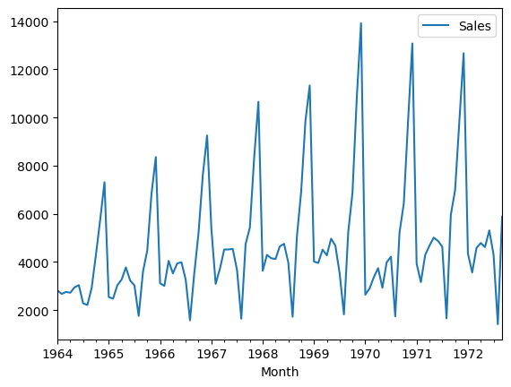

```python
df.plot()
```

- #### Testing For Stationarity : When a time series is stationary, it can be easier to model.
- #### "adfuller" is a function / module used to check the STATIONARITY in dataset.

```python
from statsmodels.tsa.stattools import adfuller
```

```python
test_result=adfuller(df['Sales'])
```

```python
#HYPOTHESIS TEST:
#Ho: It is non stationary
#H1: It is stationary

def adfuller_test(sales):

    result=adfuller(sales)

    labels = ['ADF Test Statistic','p-value','#Lags Used','Number of Observations Used']

    for value,label in zip(result,labels):
        print(label+' : '+str(value) )

    if result[1] <= 0.05:
        print("strong evidence against the null hypothesis(Ho), reject the null hypothesis. Data has no unit root and is stationary")
    else:
        print("weak evidence against null hypothesis, time series has a unit root, indicating it is non-stationary ")
```

```python
adfuller_test(df['Sales'])
```

```
ADF Test Statistic : -1.8335930563276228
p-value : 0.363915771660245
#Lags Used : 11
Number of Observations Used : 93
weak evidence against null hypothesis, time series has a unit root, indicating it is non-stationary
```

#### DIFFERENCING:

- Differencing is a popular and widely used data transform for making time series data stationary.
- Differencing can help stabilise the mean of a time series by removing changes in the level of a time series, and therefore eliminating (or reducing) trend and seasonality.
- Differencing shifts ONE/MORE row towards downwards.

```python
df['Seasonal First Difference']=df['Sales']-df['Sales'].shift(12)
```

##### Here the value 12 is the number of index values per period of time you are calculating.

```python
df.head(14)
```

| Month | Sales | Seasonal First Difference |
| --- | --- | --- |
| 1964-01-01 | 2815.0 | NaN |
| 1964-02-01 | 2672.0 | NaN |
| 1964-03-01 | 2755.0 | NaN |
| 1964-04-01 | 2721.0 | NaN |
| 1964-05-01 | 2946.0 | NaN |
| 1964-06-01 | 3036.0 | NaN |
| 1964-07-01 | 2282.0 | NaN |
| 1964-08-01 | 2212.0 | NaN |
| 1964-09-01 | 2922.0 | NaN |
| 1964-10-01 | 4301.0 | NaN |
| 1964-11-01 | 5764.0 | NaN |
| 1964-12-01 | 7312.0 | NaN |
| 1965-01-01 | 2541.0 | -274.0 |
| 1965-02-01 | 2475.0 | -197.0 |

```python
## Again test dickey fuller test
adfuller_test(df['Seasonal First Difference'].dropna())
```

```
ADF Test Statistic : -7.626619157213164
p-value : 2.060579696813685e-11
#Lags Used : 0
Number of Observations Used : 92
strong evidence against the null hypothesis(Ho), reject the null hypothesis. Data has no unit root and is stationary
```

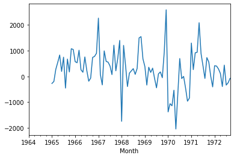

```python
df['Seasonal First Difference'].plot()
```

#### NOW OUR DATA IS STATIONARY.

### AUTO-CORRELATION | PARTIAL AUTO-CORRELATION:

```python
from statsmodels.graphics.tsaplots import plot_acf,plot_pacf
```

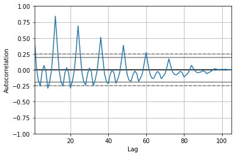

```python
from pandas.plotting import autocorrelation_plot
autocorrelation_plot(df['Sales'])
plt.show()
```

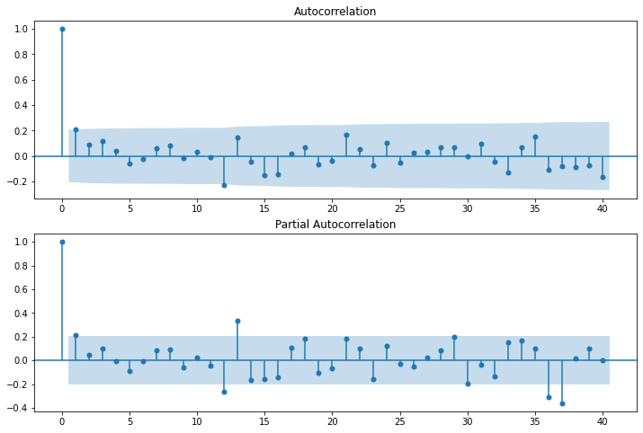

```python
import statsmodels.api as sm
fig = plt.figure(figsize=(12,8))
ax1 = fig.add_subplot(211)
fig = sm.graphics.tsa.plot_acf(df['Seasonal First Difference'].iloc[13:],lags=40,ax=ax1)
ax2 = fig.add_subplot(212)
fig = sm.graphics.tsa.plot_pacf(df['Seasonal First Difference'].iloc[13:],lags=40,ax=ax2)
```

#### Here these two graphs will help you to find the p and q values.

- Partial AutoCorrelation Graph is for the p-value.
- AutoCorrelation Graph for the q-value.

### 3. ARIMA MODEL

Let’s Break it Down:-

- AR: Autoregression. A model that uses the dependent relationship between an observation and some number of lagged observations.
- I: Integrated. The use of differencing of raw observations in order to make the time series stationary.
- MA: Moving Average. A model that uses the dependency between an observation and a residual error from a moving average model applied to lagged observations.

The parameters of the ARIMA model are defined as follows:

- p: The number of lag observations included in the model, also called the lag order.
- d: The number of times that the raw observations are differenced, also called the degree of differencing.
- q: The size of the moving average window, also called the order of moving average.

```python
# For non-seasonal data
#p=1, d=1, q=0 or 1
from statsmodels.tsa.arima_model import ARIMA
```

```python
model=ARIMA(df['Sales'],order=(1,1,1))
model_fit=model.fit()
```

[output not shown]

```python
model_fit.summary()
```

ARIMA Model Results

| Dep. Variable: | D.Sales | No. Observations: | 104 |
| --- | --- | --- | --- |
| Model: | ARIMA(1, 1, 1) | Log Likelihood | -951.126 |
| Method: | css-mle | S.D. of innovations | 2227.263 |
| Date: | Fri, 30 Apr 2021 | AIC | 1910.251 |
| Time: | 10:19:32 | BIC | 1920.829 |
| Sample: | 02-01-1964 | HQIC | 1914.536 |
|  | - 09-01-1972 |  |  |

|  | coef | std err | z | P>\|z\| | [0.025 | 0.975] |
| --- | --- | --- | --- | --- | --- | --- |
| const | 22.7843 | 12.405 | 1.837 | 0.066 | -1.530 | 47.098 |
| ar.L1.D.Sales | 0.4343 | 0.089 | 4.866 | 0.000 | 0.259 | 0.609 |
| ma.L1.D.Sales | -1.0000 | 0.026 | -38.503 | 0.000 | -1.051 | -0.949 |

Roots

|  | Real | Imaginary | Modulus | Frequency |
| --- | --- | --- | --- | --- |
| AR.1 | 2.3023 | +0.0000j | 2.3023 | 0.0000 |
| MA.1 | 1.0000 | +0.0000j | 1.0000 | 0.0000 |

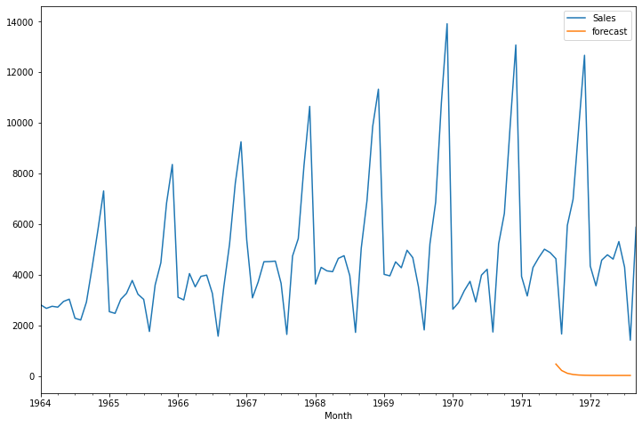

```python
df['forecast']=model_fit.predict(start=90,end=103,dynamic=True)
df[['Sales','forecast']].plot(figsize=(12,8))
```